# Practical Machine Learning Assignment

Rafael Lohn

September 21, 2014

First I took a look at the data and decided that the indexes and name of the subjects should not be necessary. Moreover, from the nature of the measurements, I decided also not to use the date-time data.

```r
data<-read.csv("pml-training.csv")
dimOriginal<-dim(data)[2]
```

```r
columnsToRemove<-c('X','user_name','raw_timestamp_part_1','raw_timestamp_part_2','cvtd_timestamp','new_window')
data <- data[,!(names(data) %in% columnsToRemove)]
remove(columnsToRemove)
```

Then, I proceeded to remove the variables that had only NAs and the variables that had no measurement (empty or divisions by zero).

```r
columnCountNA<-colSums(is.na(data))
data <- data[,columnCountNA< 10]
remove(columnCountNA)
columnCountEmpty<-colSums(data=="")+colSums(data=="#DIV/0!")
data <- data[,columnCountEmpty< 10]
remove(columnCountEmpty)
```

```r
k = 5
data$id <- sample(1:k, nrow(data), replace = TRUE)
list <- 1:k
```

With this steps I went from 160 variables to 56. And, having only 19622 observations, I decided to work with a 5-fold for cross validation. It seems like a good balance of number of chunks versus size of the sample.

My first approach was to try a simple prediction with trees.

```r
predictionTotal <- data.frame()
testTotal <- data.frame()

for (i in 1:k){
  training <- subset(data, id %in% list[-i])
  testCurrent <- subset(data, id %in% c(i))
  model <-train(classe ~.,method='rpart',data=training)
  predictionCurrent <- as.data.frame(predict(model, testCurrent[,-55]))
  predictionTotal <- rbind(predictionTotal, predictionCurrent)
  testTotal <- rbind(testTotal, as.data.frame(testCurrent[,55]))
}
result <- cbind(predictionTotal, testTotal[, 1])
names(result) <- c("Predicted", "Actual")
rPart<-sum(result$Actual==result$Predicted)/dim(result)[1]
table(result$Actual,result$Predicted)
```

```
##
##        A    B    C    D    E
##   A 4977   84  487    0   32
##   B 1312 1286 1199    0    0
##   C 1164  108 2150    0    0
##   D 1053  569 1479    0  115
##   E  307  324  886    0 2090
```

This model gave me an average result of 53.5267% correct classifications. Curiously, it did not predict any ‘classe’ of type D. Not good.

The second approach was the Random Forest model.

```r
predictionTotal <- data.frame()
testTotal <- data.frame()

for (i in 1:k){
  training <- subset(data, id %in% list[-i])
  testCurrent <- subset(data, id %in% c(i))
  model <- randomForest(training$classe ~ ., data = training)
  predictionCurrent <- as.data.frame(predict(model, testCurrent[,-55]))
  predictionTotal <- rbind(predictionTotal, predictionCurrent)
  testTotal <- rbind(testTotal, as.data.frame(testCurrent[,55]))
}
result <- cbind(predictionTotal, testTotal[, 1])
names(result) <- c("Predicted", "Actual")
randomForest<-sum(result$Actual==result$Predicted)/dim(result)[1]
table(result$Actual,result$Predicted)
```

```
##
##        A    B    C    D    E
##   A 5579    1    0    0    0
##   B    5 3790    2    0    0
##   C    0   10 3412    0    0
##   D    0    0   17 3197    2
##   E    0    0    0    6 3601
```

This model gave me an average result of 99.7809% correct classifications. This approach seemed - as expected - very good.

I decided to follow with a Stochastic Gradient Boosting model to try to improve the Random Forest result. It took much longer than the previous calculations and in all my atempts… crashed my computer:

[figure not shown]

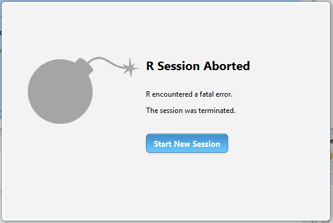